# STAT 571/701 Modern Data Mining, HW 2

Yuzhou Lin

Lingqi Zhang

Shaolong Wu

Due: 11:59 PM, Sunday, 02/28

# Overview

Principle Component Analysis is widely used in data exploration, dimension reduction, data visualization. The aim is to transform original data into uncorrelated linear combinations of the original data while keeping the information contained in the data. High dimensional data tends to show clusters in lower dimensional view.

Clustering Analysis is another form of EDA. Here we are hoping to group data points which are close to each other within the groups and far away between different groups. Clustering using PC’s can be effective. Clustering analysis can be very subjective in the way we need to summarize the properties within each group.

Both PCA and Clustering Analysis are so called unsupervised learning. There is no response variables involved in the process.

For supervised learning, we try to find out how does a set of predictors relate to some response variable of the interest. Multiple regression is still by far, one of the most popular methods. We use linear models as a working model for its simplicity and interpretability. It is important that we use domain knowledge as much as we can to determine the form of the response as well as the function format of the factors.

## 0.1 Objectives

- PCA
- SVD
- Clustering Analysis
- Linear Regression

## 0.2 Review materials

- Study Module 2: PCA
- Study Module 3: Clustering Analysis
- Study lecture 4: Multiple regression

# 1 Case study 1: Self-seteem

Self-esteem generally describes a person’s overall sense of self-worthiness and personal value. It can play significant role in one’s motivation and success throughout the life. Factors that influence self-esteem can be inner thinking, health condition, age, life experiences etc. We will try to identify possible factors in our data that are related to the level of self-esteem.

In the well-cited National Longitudinal Study of Youth (NLSY79), it follows about 13,000 individuals and numerous individual-year information has been gathered through surveys. The survey data is open to public [here](https://www.nlsinfo.org/investigator/). Among many variables we assembled a subset of variables including personal demographic variables in different years, household environment in 79, ASVAB test Scores in 81 and Self-Esteem scores in 81 and 87 respectively.

The data is store in `NLSY79.csv`.

Here are the description of variables:

**Personal Demographic Variables**

- Gender: a factor with levels “female” and “male”
- Education05: years of education completed by 2005
- HeightFeet05, HeightInch05: height measurement. For example, a person of 5’10 will be recorded as HeightFeet05=5, HeightInch05=10.
- Weight05: weight in lbs.
- Income87, Income05: total annual income from wages and salary in 2005.
- Job87, Job05: job type in 1987 and 2005, including Protective Service Occupations, Food Preparation and Serving Related Occupations, Cleaning and Building Service Occupations, Entertainment Attendants and Related Workers, Funeral Related Occupations, Personal Care and Service Workers, Sales and Related Workers, Office and Administrative Support Workers, Farming, Fishing and Forestry Occupations, Construction Trade and Extraction Workers, Installation, Maintenance and Repairs Workers, Production and Operating Workers, Food Preparation Occupations, Setters, Operators and Tenders, Transportation and Material Moving Workers

**Household Environment**

- Imagazine: a variable taking on the value 1 if anyone in the respondent’s household regularly read magazines in 1979, otherwise 0
- Inewspaper: a variable taking on the value 1 if anyone in the respondent’s household regularly read newspapers in 1979, otherwise 0
- Ilibrary: a variable taking on the value 1 if anyone in the respondent’s household had a library card in 1979, otherwise 0
- MotherEd: mother’s years of education
- FatherEd: father’s years of education
- FamilyIncome78

**Variables Related to ASVAB test Scores in 1981**

| Test | Description |
| --- | --- |
| AFQT | percentile score on the AFQT intelligence test in 1981 |
| Coding | score on the Coding Speed test in 1981 |
| Auto | score on the Automotive and Shop test in 1981 |
| Mechanic | score on the Mechanic test in 1981 |
| Elec | score on the Electronics Information test in 1981 |
| Science | score on the General Science test in 1981 |
| Math | score on the Math test in 1981 |
| Arith | score on the Arithmetic Reasoning test in 1981 |
| Word | score on the Word Knowledge Test in 1981 |
| Parag | score on the Paragraph Comprehension test in 1981 |
| Numer | score on the Numerical Operations test in 1981 |

**Self-Esteem test 81 and 87**

We have two sets of self-esteem test, one in 1981 and the other in 1987. Each set has same 10 questions. They are labeled as `Esteem81` and `Esteem87` respectively followed by the question number. For example, `Esteem81_1` is Esteem question 1 in 81.

The following 10 questions are answered as 1: strongly agree, 2: agree, 3: disagree, 4: strongly disagree

- Esteem 1: “I am a person of worth”
- Esteem 2: “I have a number of good qualities”
- Esteem 3: “I am inclined to feel like a failure”
- Esteem 4: “I do things as well as others”
- Esteem 5: “I do not have much to be proud of”
- Esteem 6: “I take a positive attitude towards myself and others”
- Esteem 7: “I am satisfied with myself”
- Esteem 8: “I wish I could have more respect for myself”
- Esteem 9: “I feel useless at times”
- Esteem 10: “I think I am no good at all”

## 1.1 Data preparation

Load the data. Do a quick EDA to get familiar with the data set. Pay attention to the unit of each variable. Are there any missing values?

## 1.2 Self esteem evaluation

Let concentrate on Esteem scores evaluated in 87.

1. Reverse Esteem 1, 2, 4, 6, and 7 so that a higher score corresponds to higher self-esteem. (Hint: if we store the esteem data in `data.esteem`, then `data.esteem[, c(1, 2, 4, 6, 7)] <- 5 - data.esteem[, c(1, 2, 4, 6, 7)]` to reverse the score.)
2. Write a brief summary with necessary plots about the 10 esteem measurements.
3. Do esteem scores all positively correlated? Report the pairwise correlation table and write a brief summary.
4. PCA on 10 esteem measurements. (centered but no scaling)
   1. Report the PC1 and PC2 loadings. Are they unit vectors? Are they uncorrelated?
   2. Are there good interpretations for PC1 and PC2? (If loadings are all negative, take the positive loadings for the ease of interpretation)
   3. How is the PC1 score obtained for each subject? Write down the formula.
   4. Are PC1 scores and PC2 scores in the data uncorrelated?
   5. Plot PVE (Proportion of Variance Explained) and summarize the plot.
   6. Also plot CPVE (Cumulative Proportion of Variance Explained). What proportion of the variance in the data is explained by the first two principal components?
   7. PC’s provide us with a low dimensional view of the self-esteem scores. Use a biplot with the first two PC’s to display the data. Give an interpretation of PC1 and PC2 from the plot. (try `ggbiplot` if you could, much prettier!)
5. Apply k-means to cluster subjects on the original esteem scores
   1. Find a reasonable number of clusters using within sum of squared with elbow rules.
   2. Can you summarize common features within each cluster?
   3. Can you visualize the clusters with somewhat clear boundaries? You may try different pairs of variables and different PC pairs of the esteem scores.
6. We now try to find out what factors are related to self-esteem? PC1 of all the Esteem scores is a good variable to summarize one’s esteem scores. We take PC1 as our response variable.
   1. Prepare possible factors:
   - Personal information: gender, education, log(income), job type, Body mass index as a measure of health (The BMI is defined as the body mass divided by the square of the body height, and is universally expressed in units of kg/m²)
   - Household environment: Imagazine, Inewspaper, Ilibrary, MotherEd, FatherEd, FamilyIncome78. Do set indicators `Imagazine` and `Ilibrary` as factors
   - Use PC1 of SVABS as level of intelligence
   2. Run a few regression models between PC1 of all the esteem scores and factors listed in a). Find a final best model with your own criterion.
   - How did you land this model? Run a model diagnosis to see if the linear model assumptions are reasonably met.
   - Write a summary of your findings. In particular, explain what and how the variables in the model affect one’s self-esteem.

# 2 Case study 2: Breast cancer sub-type

[The Cancer Genome Atlas (TCGA)](https://www.cancer.gov/about-nci/organization/ccg/research/structural-genomics/tcga), a landmark cancer genomics program by National Cancer Institute (NCI), molecularly characterized over 20,000 primary cancer and matched normal samples spanning 33 cancer types. The genome data is open to public from the [Genomic Data Commons Data Portal (GDC)](https://portal.gdc.cancer.gov/).

In this study, we focus on 4 sub-types of breast cancer (BRCA): basal-like (basal), Luminal A-like (lumA), Luminal B-like (lumB), HER2-enriched. The sub-type is based on PAM50, a clinical-grade luminal-basal classifier.

- Luminal A cancers are low-grade, tend to grow slowly and have the best prognosis.
- Luminal B cancers generally grow slightly faster than luminal A cancers and their prognosis is slightly worse.
- HER2-enriched cancers tend to grow faster than luminal cancers and can have a worse prognosis, but they are often successfully treated with targeted therapies aimed at the HER2 protein.
- Basal-like breast cancers or triple negative breast cancers do not have the three receptors that the other sub-types have so have fewer treatment options.

We will try to use mRNA expression data alone without the labels to classify 4 sub-types. Classification without labels or prediction without outcomes is called unsupervised learning. We will use K-means and spectrum clustering to cluster the mRNA data and see whether the sub-type can be separated through mRNA data.

We first read the data using `data.table::fread()` which is a faster way to read in big data than `read.csv()`.

1. Summary and transformation
1. How many patients we have in each sub-type?

**Student Answer:** 208 patients for Basal sub-type, 91 for Her2, 628 for LumA, and 233 for LumB.

```r
brca_subtype %>%
  group_by(BRCA_Subtype_PAM50) %>%
  summarise(n())
```

```
## # A tibble: 4 x 2
##   BRCA_Subtype_PAM50 `n()`
## * <chr>              <int>
## 1 Basal                208
## 2 Her2                  91
## 3 LumA                 628
## 4 LumB                 233
```

2. Randomly pick 5 genes and plot the histogram by each sub-type.

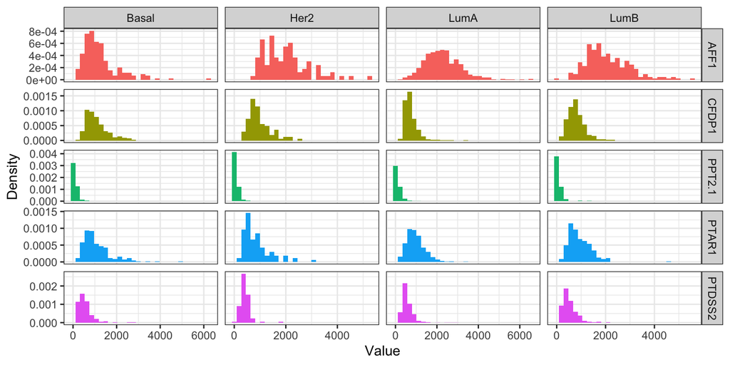

```r
set.seed(2048)
n_gene <- 5

sample_idx <- sample(ncol(brca), n_gene)
plot_data  <- select(brca, all_of(sample_idx))
plot_data$TYPE <- brca_subtype$BRCA_Subtype_PAM50

plot_data %>%
  pivot_longer(cols = 1:n_gene)  %>%
  group_by(TYPE, name) %>%
  ggplot(aes(x = value)) +
  geom_histogram(aes(y=..density.., fill = name)) +
  facet_grid(name ~ TYPE, scales = "free") +
  labs(x = 'Value', y = 'Density') +
  theme_bw() +
  theme(legend.position = "none")
```

3. Remove gene with zero count and no variability. Then apply logarithmic transform.

```r
sel_cols <- which((colSums(abs(brca)) != 0) & (sapply(brca, var) > 1e-10))
brca_sub <- brca[, sel_cols, with=F]
brca_sub <- log2(brca_sub + 1e-10)
```

2. Apply kmeans on the transformed dataset with 4 centers and output the discrepancy table between the real sub-type `brca_subtype` and the cluster labels.

```r
brca_sub_kmeans <- kmeans(x = brca_sub, centers = 4, nstart = 50)
table(brca_subtype$BRCA_Subtype_PAM50, brca_sub_kmeans$cluster)
```

```
##
##           1   2   3   4
##   Basal  17   1 187   3
##   Her2    9  43  16  23
##   LumA   86 395   0 147
##   LumB   22 104   2 105
```

3. Spectrum clustering: to scale or not to scale?
1. Apply PCA on the centered and scaled dataset. How many PCs should we use and why? You are encouraged to use `irlba::irlba()`.

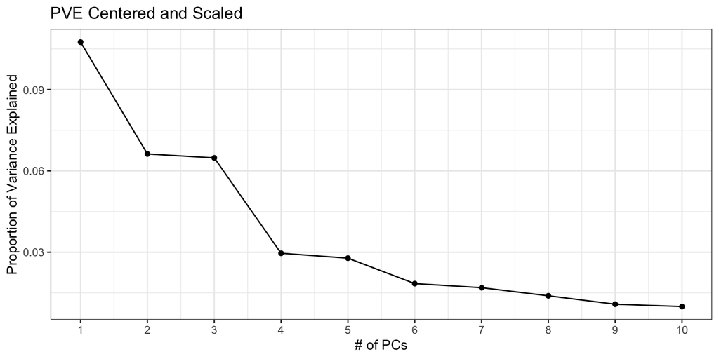

```r
pca_ct_sc <- prcomp(brca_sub, center = T, scale. = T)
pca_ct <- prcomp(brca_sub, center = T, scale. = F)
pve <- summary(pca_ct_sc)$importance[2, 1:10]

data.frame("index"=1:10, "pve"=pve) %>%
  ggplot(aes(x = index, y = pve)) +
  geom_point() + geom_line() +
  labs(title = "PVE Centered and Scaled", x = '# of PCs', y = 'Proportion of Variance Explained') +
  scale_x_continuous(breaks = 1:10) +
  theme_bw()
```

2. Plot PC1 vs PC2 of the centered and scaled data and PC1 vs PC2 of the centered but unscaled data side by side. Should we scale or not scale for clustering propose? Why? (Hint: to put plots side by side, use `gridExtra::grid.arrange()` or `ggpubr::ggrrange()` or `egg::ggrrange()` for ggplots; use `fig.show="hold"` as chunk option for base plots)

**Student Answer:** We should NOT scale for clustering purpose. Since from the two plots below, the unscaled PCs can produce much better separation of different cancer types (especially the difference between Basal and Her2 Type).

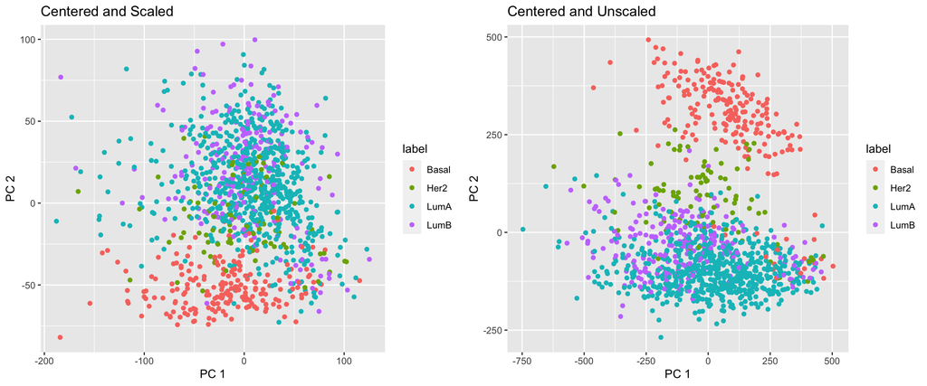

```r
plot_1 <-
  data.table(x = pca_ct_sc$x[, 1],
           y = pca_ct_sc$x[, 2],
           label = as.factor(brca_subtype$BRCA_Subtype_PAM50)) %>%
  ggplot() +
  geom_point(aes(x = x, y = y, col = label)) +
  labs(title = "Centered and Scaled", x = 'PC 1', y = 'PC 2')

plot_2 <-
  data.table(x = pca_ct$x[, 1],
           y = pca_ct$x[, 2],
           label = as.factor(brca_subtype$BRCA_Subtype_PAM50),
           cluster = as.factor(brca_sub_kmeans$cluster)) %>%
  ggplot() +
  geom_point(aes(x = x, y = y, col = label)) +
  labs(title = "Centered and Unscaled", x = 'PC 1', y = 'PC 2')

grid.arrange(plot_1, plot_2, ncol = 2)
```

4. Spectrum clustering: center but do not scale the data
1. Use the first 4 PCs of the centered and unscaled data and apply kmeans. Find a reasonable number of clusters using within sum of squared with the elbow rule.

**Student Answer:** K = 4 is a reasonable number for cluster according to the elbow rule (although in our particular case the location of the “elbow” is slightly ambiguous).

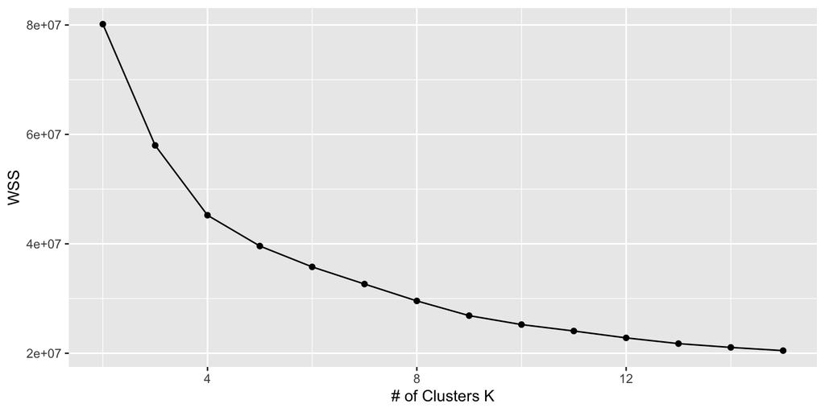

```r
wss <- function(df, k)
{
  kmeans(df, k, nstart = 10)$tot.withinss
}

num_k <- 2:15
wss_values <- map_dbl(num_k, function(k) wss(pca_ct$x[, 1:4], k))

data.frame("k" = num_k, "wss" = wss_values) %>%
  ggplot(aes(x = k, y = wss)) +
  geom_point() + geom_line() +
  labs(x = '# of Clusters K', y = 'WSS')
```

2. Choose an optimal cluster number and apply kmeans. Compare the real sub-type and the clustering label as follows: Plot scatter plot of PC1 vs PC2. Use point color to indicate the true cancer type and point shape to indicate the clustering label. Plot the kmeans centroids with black dots. Summarize how good is clustering results compared to the real sub-type.

**Student Answer:** The clustering algorithm can successfully distinguish between the Basal vs. LumA/B subtype. A large portion of LumA subtype is also isolated from the rest. However, the Her2 subtype cannot be well separated from the rest, and there are also many mislabeling within LumA/B subtype.

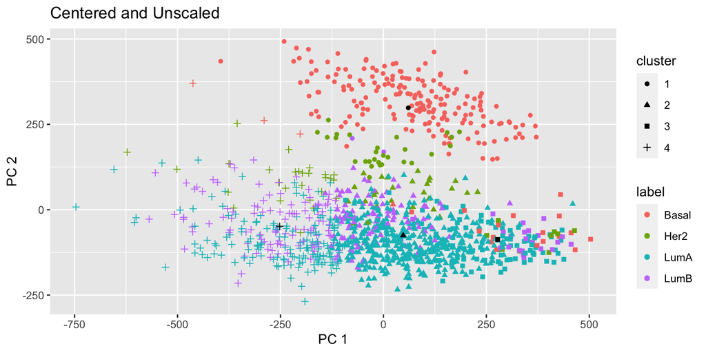

```r
n_cluster <- 4
n_PCs <- 4

pca_ct_kmeans <- kmeans(x = pca_ct$x[, 1:n_PCs], centers = n_cluster, nstart = 100)
centroids <- data.frame(pca_ct_kmeans$centers[, 1:2])
centroids$cluster = as.factor(1:n_cluster)

plot_data <- data.table(x = pca_ct$x[, 1],
                        y = pca_ct$x[, 2],
                        label = as.factor(brca_subtype$BRCA_Subtype_PAM50),
                        cluster = as.factor(pca_ct_kmeans$cluster))

ggplot() +
geom_point(data = plot_data, aes(x = x, y = y, col = label, shape = cluster)) +
geom_point(data = centroids, aes(x = PC1, y = PC2, shape = cluster)) +
labs(title = "Centered and Unscaled", x = 'PC 1', y = 'PC 2')
```

3. Compare the clustering result from applying kmeans to the original data and the clustering result from applying kmeans to 4 PCs. Does PCA help in kmeans clustering? What might be the reasons if PCA helps?

**Student Answer:** In this case, PCA did NOT help in kmeans clustering in terms of the quality of the cluster. The only improvement is that the kmeans algorithm runs much faster with only 4 PCs. In general, PCA might help clustering since it picks up dimensions that are more important, thus can help reduce the noise in clustering.

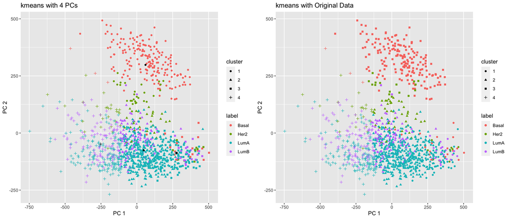

```r
plot_1 <-
  ggplot() +
  geom_point(data = plot_data, aes(x = x, y = y, col = label, shape = cluster)) +
  geom_point(data = centroids, aes(x = PC1, y = PC2, shape = cluster)) +
  labs(title = "kmeans with 4 PCs", x = 'PC 1', y = 'PC 2')

plot_2 <-
  data.table(x = pca_ct$x[, 1],
             y = pca_ct$x[, 2],
             label = as.factor(brca_subtype$BRCA_Subtype_PAM50),
             cluster = as.factor(brca_sub_kmeans$cluster)) %>%
  ggplot() +
  geom_point(aes(x = x, y = y, col = label, shape = cluster)) +
  labs(title = "kmeans with Original Data", x = 'PC 1', y = 'PC 2')

grid.arrange(plot_1, plot_2, ncol = 2)
```

```r
print("Kmeans with Original Data")
```

```
## [1] "Kmeans with Original Data"
```

```r
table(brca_subtype$BRCA_Subtype_PAM50, brca_sub_kmeans$cluster)
```

```
##
##           1   2   3   4
##   Basal  17   1 187   3
##   Her2    9  43  16  23
##   LumA   86 395   0 147
##   LumB   22 104   2 105
```

```r
print("Kmeans with 4PCs")
```

```
## [1] "Kmeans with 4PCs"
```

```r
table(brca_subtype$BRCA_Subtype_PAM50, pca_ct_kmeans$cluster)
```

```
##
##           1   2   3   4
##   Basal 187   1  17   3
##   Her2   28  27   9  27
##   LumA    0 376  91 161
##   LumB    2  99  22 110
```

4. Now we have an x patient with breast cancer but with unknown sub-type. We have this patient’s mRNA sequencing data. Project this x patient to the space of PC1 and PC2. (Hint: remember we remove some gene with no counts or no variablity, take log and centered) Plot this patient in the plot in iv) with a black dot. Calculate the Euclidean distance between this patient and each of centroid of the cluster. Can you tell which sub-type this patient might have?

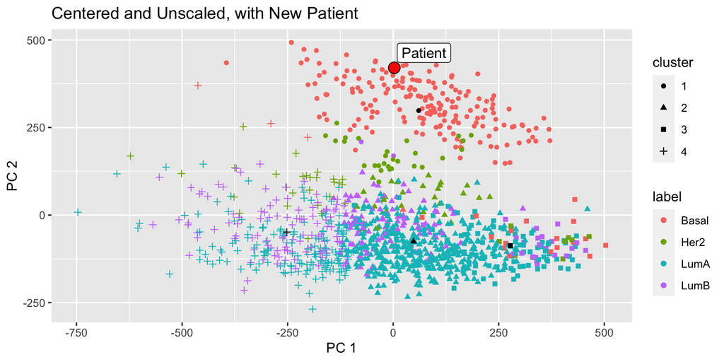

```r
x_patient <- fread("data/brca_x_patient.csv")
x_patient <- log2(x_patient[, sel_cols, with=F] + 1e-10) - pca_ct$center

patient = data.frame("PC1" = as.matrix(x_patient[1, ]) %*% as.matrix(pca_ct$rotation[, 1]),
                     "PC2" = as.matrix(x_patient[1, ]) %*% as.matrix(pca_ct$rotation[, 2]))

ggplot() +
geom_point(data = plot_data, aes(x = x, y = y, col = label, shape = cluster)) +
geom_point(data = centroids, aes(x = PC1, y = PC2, shape = cluster)) +
geom_point(data = patient, aes(x = PC1, y = PC2), shape = 21, size = 4, fill = 'red') +
ggrepel::geom_label_repel(data = patient, aes(x = PC1, y = PC2), label = "Patient", size = 4) +
labs(title = "Centered and Unscaled, with New Patient", x = 'PC 1', y = 'PC 2')
```

```r
for (idx in 1:4)
{
  print(norm(as.matrix(centroids[idx, 1:2]) - as.matrix(patient[1, ])))
}
```

```
## [1] 122
## [1] 496
## [1] 508
## [1] 469
```

# 3 Case study 3: Auto data set

Get familiar with this dataset first. Tip: you can use the command `?ISLR::Auto` to view a description of the dataset.

## 3.1 EDA

Explore the data, with particular focus on pairwise plots and summary statistics. Briefly summarize your findings and any peculiarities in the data.

## 3.2 What effect does `time` have on `MPG`?

1. Start with a simple regression of `mpg` vs. `year` and report R’s `summary` output. Is `year` a significant variable at the .05 level? State what effect `year` has on `mpg`, if any, according to this model.
2. Add `horsepower` on top of the variable `year` to your linear model. Is `year` still a significant variable at the .05 level? Give a precise interpretation of the `year`’s effect found here.
3. The two 95% CI’s for the coefficient of year differ among (i) and (ii). How would you explain the difference to a non-statistician?
4. Create a model with interaction by fitting `lm(mpg ~ year * horsepower)`. Is the interaction effect significant at .05 level? Explain the year effect (if any).

## 3.3 Categorical predictors

Remember that the same variable can play different roles! Take a quick look at the variable `cylinders`, and try to use this variable in the following analyses wisely. We all agree that a larger number of cylinders will lower mpg. However, we can interpret `cylinders` as either a continuous (numeric) variable or a categorical variable.

1. Fit a model that treats `cylinders` as a continuous/numeric variable. Is `cylinders` significant at the 0.01 level? What effect does `cylinders` play in this model?
2. Fit a model that treats `cylinders` as a categorical/factor. Is `cylinders` significant at the .01 level? What is the effect of `cylinders` in this model? Describe the `cylinders` effect over `mpg`.
3. What are the fundamental differences between treating `cylinders` as a continuous and categorical variable in your models?
4. Can you test the null hypothesis: fit0: `mpg` is linear in `cylinders` vs. fit1: `mpg` relates to `cylinders` as a categorical variable at .01 level?

## 3.4 Results

Final modeling question: we want to explore the effects of each feature as best as possible. You may explore interactions, feature transformations, higher order terms, or other strategies within reason. The model(s) should be as parsimonious (simple) as possible unless the gain in accuracy is significant from your point of view.

1. Describe the final model. Include diagnostic plots with particular focus on the model residuals and diagnoses.
2. Summarize the effects found.
3. Predict the `mpg` of the following car: A red car built in the US in 1983 that is 180 inches long, has eight cylinders, displaces 350 cu. inches, weighs 4000 pounds, and has a horsepower of 260. Also give a 95% CI for your prediction.